# SOC-GA 2332 Intro to Stats Lab 3 Exercise solution

Di Zhou

2/19/2021

```r
knitr::opts_chunk$set(echo = TRUE)

# Load package
library(tidyverse)

# Import data
weight_df <- read.csv("data/weight.csv")
```

### Part 1 Exercise

Create a sampling distribution of the sample mean  
(1) Create a virtual population that follows a normal distribution of mean = 0 and variance = 1, with 10,000 observations. *Hint*: use `rnorm()`.  
(2) Use this population and a `for`-loop, get a sampling distribution of the sample mean by sampling 100 observations from the population for 1,000 times.  
(3) Plot a histogram of your sampling distribution of the sample mean. You can add lines for mean and SD as demonstrated in the figure above.

*Note:* Use the `set.seed()` function every time you perform a random process. That is, add the `set.seed()` function before every part of your code that involves a random process and run the `set.seed()` function together with that code for every run.

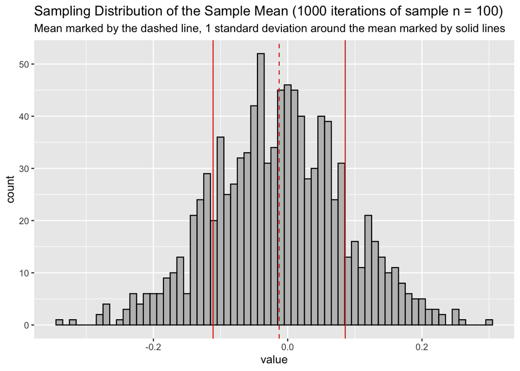

```r
set.seed(202102)

# generate population df
pop_norm <- rnorm(n = 10000, mean = 0, sd = 1) %>% as_tibble()

# create a "container" object to save the mean
mean_vec <- vector(mode = "numeric", length = 1000)

# repeatly sample from the pop df and save the mean
for (i in 1:1000){

  sample <- pop_norm %>% sample_n(size = 100, replace = FALSE)

  mean_vec[i] <- mean(sample$value)

}



# Mean and SD of the sampling distribution
mean = mean(mean_vec)
sd_pos = mean + sd(mean_vec)
sd_neg = mean - sd(mean_vec)


# Plot
mean_vec %>%
  as_tibble() %>%
  ggplot(aes(value)) +
  geom_histogram(binwidth = 0.01, fill = "grey", color = "black") +
  geom_vline(aes(xintercept = sd_neg), color = "red") +
  geom_vline(aes(xintercept = mean), color = "red", linetype = "dashed") +
  geom_vline(aes(xintercept = sd_pos), color = "red") +
  labs(title = "Sampling Distribution of the Sample Mean (1000 iterations of sample n = 100)",
       subtitle = "Mean marked by the dashed line, 1 standard deviation around the mean marked by solid lines")
```

### Part 2.1 Exercise

With $\mu_0 = 0$, $\overline y = 1.54$, sample $n = 27$, $s = 3.25$, derive:  
(1) The *t* test statistic  
(2) The critical value of *t* given $H_0$ is true  
(3) Your rejection region  
(4) P-value  
(5) Your conclusion of the significance test

```r
# First, calcuate standard error of the mean
se = 3.25/sqrt(27)    # 0.6254628

# Calculate t test statistics given null is true
observed_t = (1.54 - 0)/se  # 2.462177

# Critical value of t given null is true
qt(p = 0.5*0.05, df = 26)   # -2.055529
```

```
## [1] -2.055529
```

```r
# Rejection region is: (-inf, -2.055529) U (2.055529, inf)

# P-value
2*(1 - pt(q = observed_t, df = 26))  # 0.02075478
```

```
## [1] 0.02075478
```

```r
# Conclusion:
# Observed t is in the rejection region, so we reject the null
# Alternatively, our p-value is smaller than alpha level, so we reject the null

# You can also try the example here: https://www.geogebra.org/m/b85v7zww
```

### Calculation and functions in R

```r
# generate a random number (n = 30)
set.seed(1001)
sample <- rnorm(n = 30, mean = 2, sd = 1)

# hand code to get the sample mean
sum(sample)/length(sample)
```

```
## [1] 1.949544
```

```r
# should equal to:
mean(sample)
```

```
## [1] 1.949544
```

```r
# create a function that calculate sample mean
sample_mean <- function(x){
  mean = sum(x)/length(x)
  return(mean)
}

# try the function
sample_mean(sample)
```

```
## [1] 1.949544
```

```r
# hand code to get the sample standard deviation
sample_var <-  sum( ( sample - mean(sample) )^2 ) / (length(sample)-1)
sample_sd <- sqrt(sample_var)
sample_sd
```

```
## [1] 1.153097
```

```r
# Use base r function
sd(sample)
```

```
## [1] 1.153097
```

```r
# hand-code function
sd_example <- function(x){
  mean = sum(x)/length(x)
  variance = sum((x-mean)^2)/(length(x)-1)
  standarddeviation = sqrt(variance)
  return (standarddeviation)
}

sd_example(sample)
```

```
## [1] 1.153097
```

### Part 2.2 Exercise

The institution that offers therapy programs to the anorexic patients claims that their treatment will lead to a weight increase of 4 lbs. Use the `weight_df` data and with $\alpha = 0.05$, perform both a two-tailed and a one-tailed test:
$$H_0: \mu_{\text{change}} = 4$$

against

$$H_{\text{a1}}: \mu_{\text{change}} \neq 4 \text{ and } H_{\text{a2}}: \mu_{\text{change}} < 4$$
Report your hypothesis testing result. *Hint:* Make sure you put correct arguments for your `t.test()` function! (Are you testing for “two.sided”, “less”, or “greater”? What’s your `mu`?)

```r
# two tailed t-test
t.test(weight_df$change, mu = 4, alternative = "two.sided", conf.level = 0.95)
```

```
##
##  One Sample t-test
##
## data:  weight_df$change
## t = -1.3138, df = 71, p-value = 0.1931
## alternative hypothesis: true mean is not equal to 4
## 95 percent confidence interval:
##  0.8878354 4.6399424
## sample estimates:
## mean of x
##  2.763889
```

```r
# P-value is larger than 0.05, we do not reject the null

# one tailed t-test
t.test(weight_df$change, mu = 4, alternative = "less", conf.level = 0.95)
```

```
##
##  One Sample t-test
##
## data:  weight_df$change
## t = -1.3138, df = 71, p-value = 0.09657
## alternative hypothesis: true mean is less than 4
## 95 percent confidence interval:
##      -Inf 4.331953
## sample estimates:
## mean of x
##  2.763889
```

```r
# P-value is larger than 0.05, we do not reject the null
```

### Part 3 Exercise

Perform a two-sample two-tailed t-test for the difference between therapy b and c:

$$H_0: \mu_b - \mu_c = 0$$

against

$$H_{a}:\mu_b - \mu_c \ne 0$$

```r
# Filter data for each therapy
weight_b <- weight_df %>% filter(therapy == "b")
weight_c <- weight_df %>% filter(therapy == "c")

# two tailed two indep sample t-test
t.test(
  x = weight_b$change,          # mean value vector from the first sample
  y = weight_c$change,          # mean value vector from the second sample
  mu = 0,                       # mean difference given by your null hypothesis
  alternative = "two.sided"     # direction of alternative hypothesis
)
```

```
##
##  Welch Two Sample t-test
##
## data:  weight_b$change and weight_c$change
## t = 1.6677, df = 50.971, p-value = 0.1015
## alternative hypothesis: true difference in means is not equal to 0
## 95 percent confidence interval:
##  -0.7044632  7.6182563
## sample estimates:
## mean of x mean of y
##  3.006897 -0.450000
```

```r
# P-value is larger than 0.05, we do not reject the null
```